# PSYC40940: Grammar of Graphics

## General outline for weeks 2 – 5

- Week 2: Principles of data visualisation
- Week 3: Grammar of Graphics; aesthetics and attributes
- Week 4: Major visualisation tools
- Week 5: Customising visualisations (scales, themes, and labels)

## Objectives for today

- Understanding the principle of the Grammar of Graphics
- Differentiating between aesthetics and attributes
- Using a variety of geometries, aesthetics and attributions in data visualization
- Deciding between appropriate aesthetics for continuous and categorical variables

Download exercises from Week 3 folder on NOW and move them into your R-project directory.

## Grammar of Graphics and `ggplot2`

## What do all data visualisations have in common?

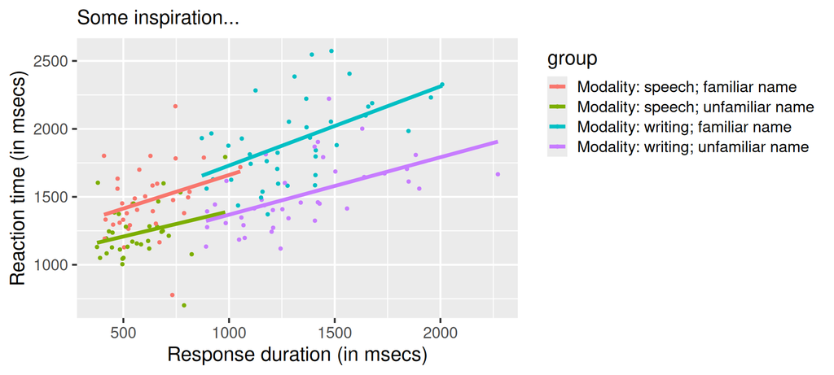

## Core copmonents

| Component | Example | Description |
| --- | --- | --- |
| **Data** | `d_spellname` | The dataset being plotted |
| **Aesthetics (aes)** | `x = dur, y = rt` | How data variables map to visual properties |
| **Geometries (geom)** | `geom_point()` | The type of plot element (points, bars, lines) |
| **Statistics (stat)** | `stat_smooth()` | Transformations of data (e.g., regression lines) |
| **Scales** | `scale_x_log10()` | How data values are converted to aesthetics |
| **Facets** | `facet_wrap(~group)` | Splitting data into small multiples |
| **Coordinate system** | `coord_polar()` | The space where data are drawn (Cartesian, polar) |
| **Theme** | `theme_minimal()` | Non-data display elements (fonts, text, grids, etc.) |

## Grammar of Graphics

### Wilkinson (2005)

- `ggplot2` is an R package for creating statistical / data graphics
- It’s based on a *Grammar of Graphics* (Wilkinson, 2005), hence “gg”
- Framework for data visualisation emphasising a layered approach.
- You assemble plots by combining independent components
- Default settings allow rapid production of high-quality plots
- The theming system allows custom styling
- See also Wickham (2016), Wickham (2010)

## Grammar of Graphics

### Wilkinson (2005)

- Fundamental features that underlie all statistical graphics.
- Grammar of Graphics answera the question “what is a statistical graphic”?
- `ggplot2` builds on Wilkinson’s grammar by focussing on the primacy of layers and adapting it for use in R (Wickham, 2010).
- Grammar describes how graphics map between **data** → **aesthetics / attributes** (colour, shape, size) → **geometric objects** (points, lines, bars).
- Higher-level plotting system (vs `plot()`, `hist()`)
- Complex visualisations can be creased with a minimal amount of code
- Supports *statistical transformations* and *coordinate systems*
- Enables *faceting* (splitting data into subsets)
- Themes control visual appearance (fonts, backgrounds, etc.)

## Grammar of Graphics

### Wilkinson (2005)

*Think about language* where grammar determines how words can be combined into sentences

- “words”: graphics consist of distinct layers of grammatical elements (data, aesthetics, geometries)
- “grammar”: graphics are built around mappings that determine how data, aesthetics and geometries are combined.
- Grammatical elements are organised as layers
- Underlying grammar controls how graphics are combined
- System of rules for mapping variables to graphical properties
- Instead of memorising “plot types,” Grammar of Graphics teaches how plots are built.
- It gives flexibility: you can create any plot by combining consistent building blocks.

## Obligatory grammatical elements

- **data:** the data you want to visualise indicated as `ggplot(data = ...)`
- **aesthetics:** mapping of data to graphic properties (axes, size, colour) indicated as `mapping = aes()`
- **geometries:** visual elements encoding the data indicated as `geom_...()`

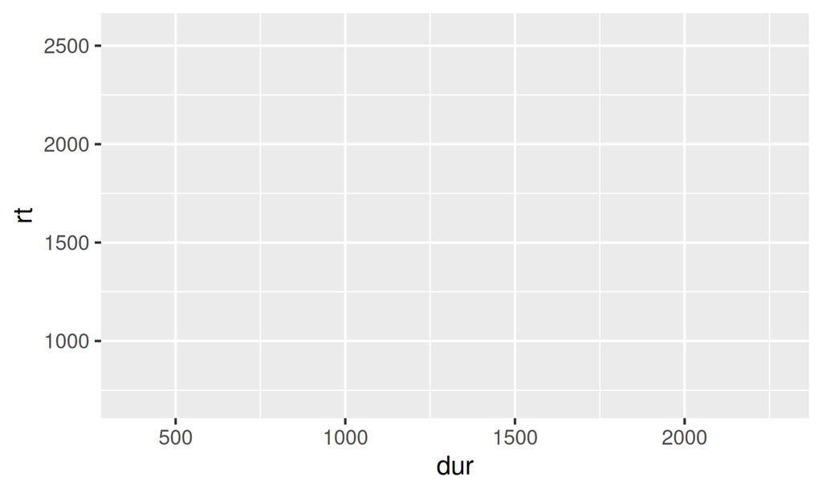

```r
ggplot(d_spellname, aes(x = dur, y = rt))
```

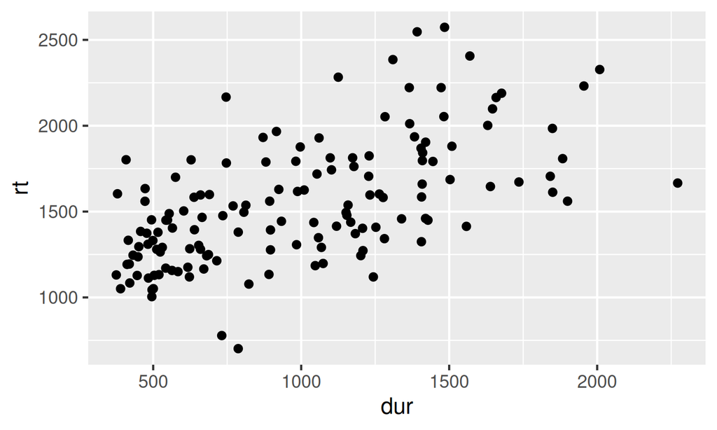

```r
ggplot(d_spellname, aes(x = dur, y = rt)) +
  geom_point()
```

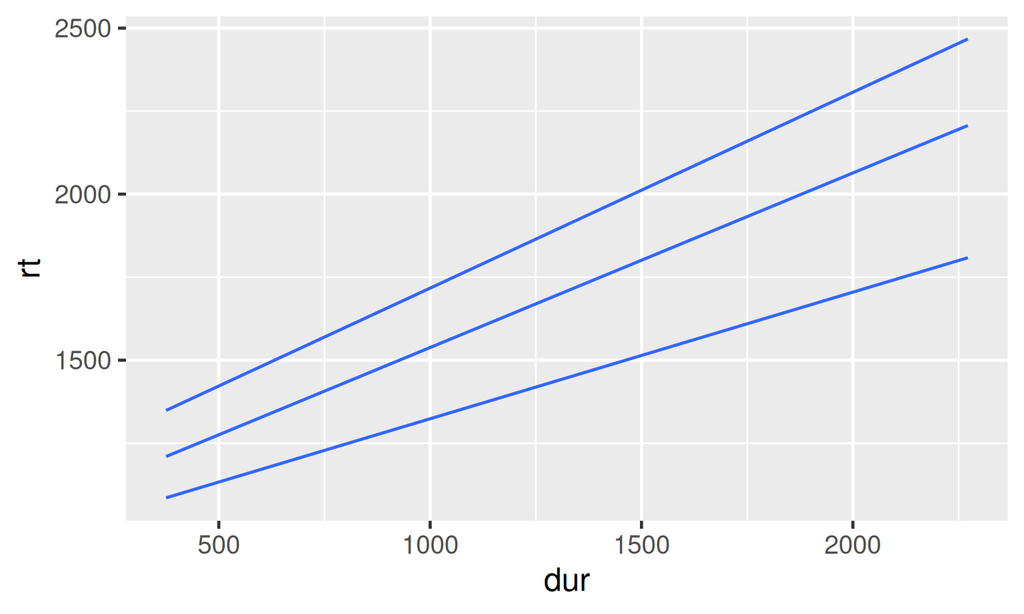

```r
ggplot(d_spellname, aes(x = dur, y = rt)) +
  geom_quantile()
```

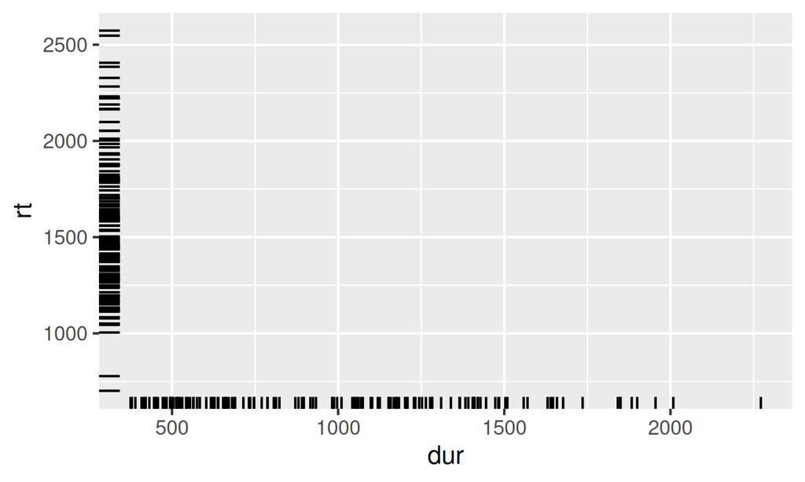

```r
ggplot(d_spellname, aes(x = dur, y = rt)) +
  geom_rug()
```

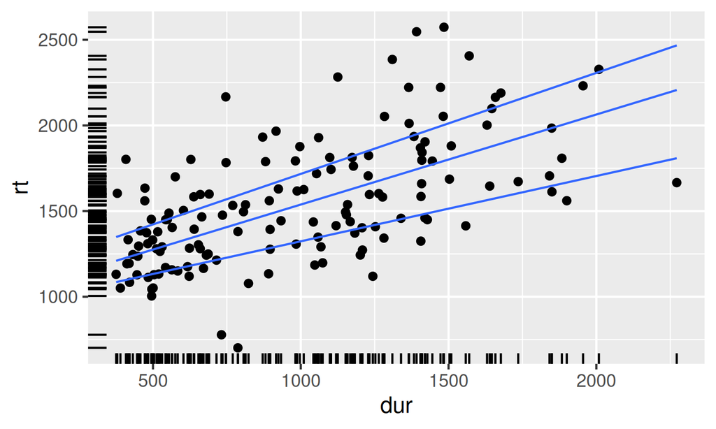

```r
ggplot(d_spellname, aes(x = dur, y = rt)) +
  geom_point() +
  geom_quantile() +
  geom_rug()
```

## Optional grammatical elements

- **facets:** dividing data into subplots
- **statistics:** summarising representations
- **coordinates:** plotting space
- **theme:** visual properties not related to the data (font, background)
- data
- aesthetics
- geometries

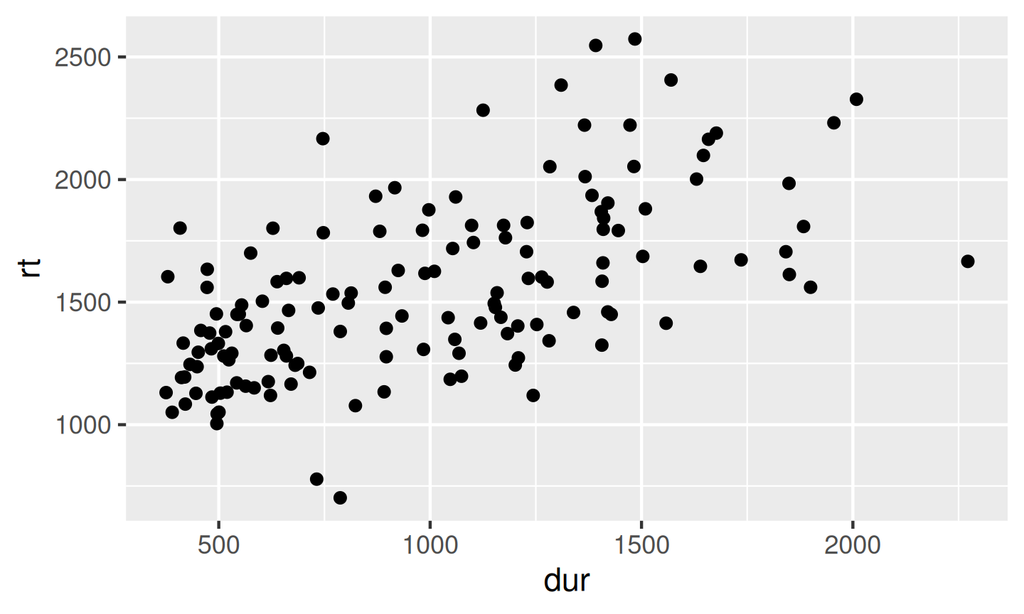

```r
ggplot(d_spellname, aes(x = dur, y = rt)) +
  geom_point()
```

- data
- aesthetics
- geometries
- facets

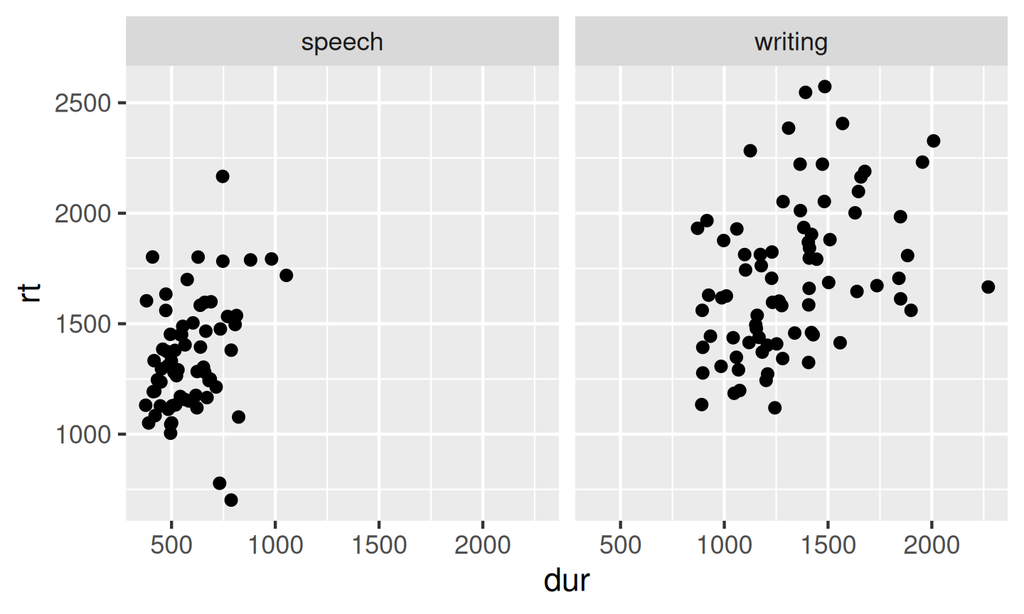

```r
ggplot(d_spellname, aes(x = dur, y = rt)) +
  geom_point() +
  facet_grid( ~ modality)
```

- data
- aesthetics
- geometries
- facets
- statistics

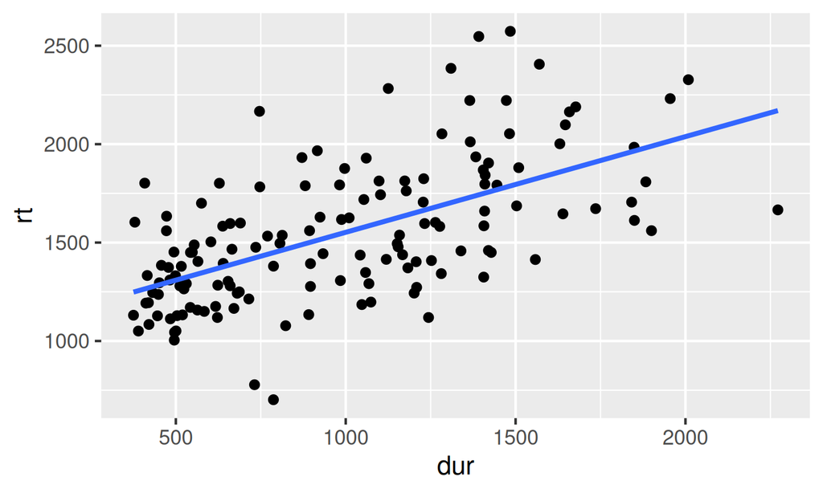

```r
ggplot(d_spellname, aes(x = dur, y = rt)) +
  geom_point() +
  stat_smooth(method = "lm", se = FALSE)
```

- data
- aesthetics
- geometries
- facets
- statistics
- coordinates

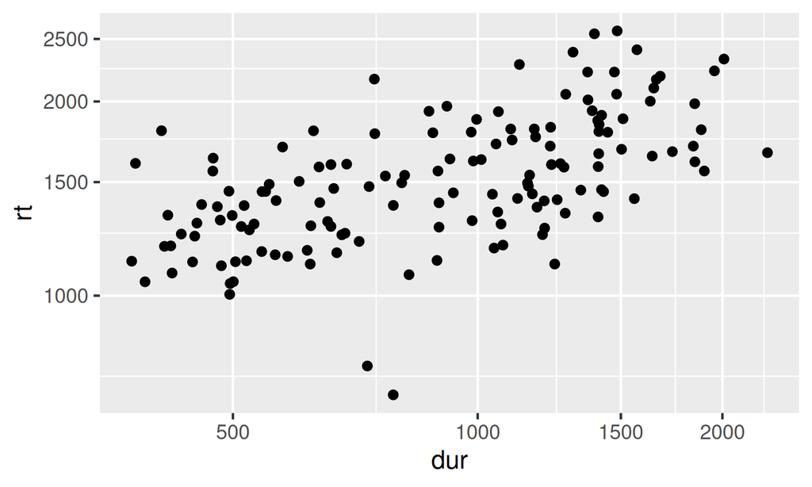

```r
ggplot(d_spellname, aes(x = dur, y = rt)) +
  geom_point() +
  coord_trans(x = "log", y = "log")
```

- data
- aesthetics
- geometries
- facets
- statistics
- coordinates

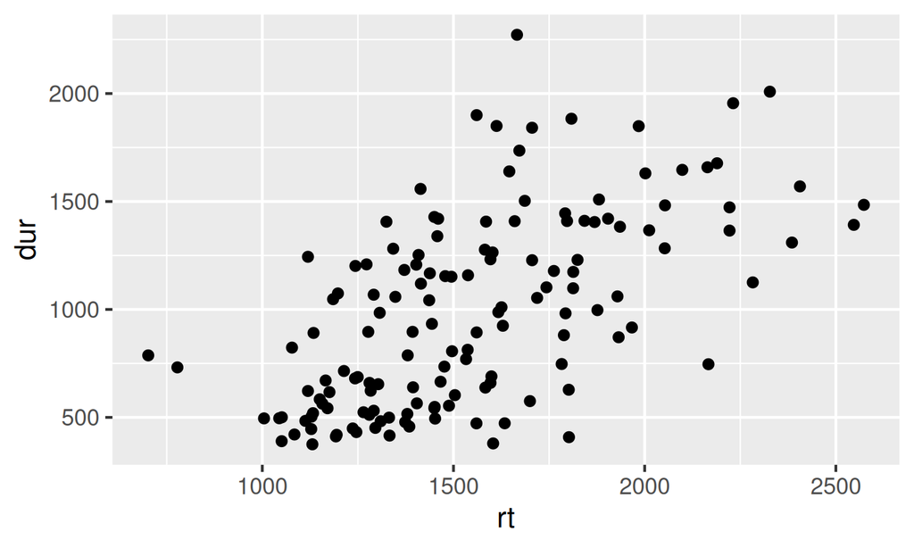

```r
ggplot(d_spellname, aes(x = dur, y = rt)) +
  geom_point() +
  coord_flip()
```

- data
- aesthetics
- geometries
- facets
- statistics
- coordinates
- theme

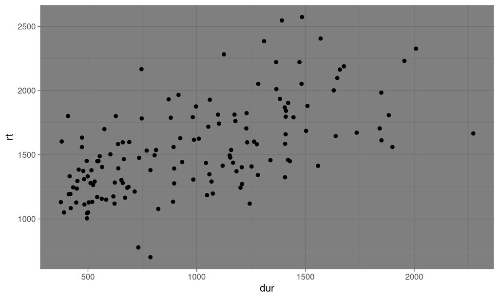

```r
ggplot(d_spellname, aes(x = dur, y = rt)) +
  geom_point() +
  theme_dark()
```

- data
- aesthetics
- geometries
- facets
- statistics
- coordinates
- theme

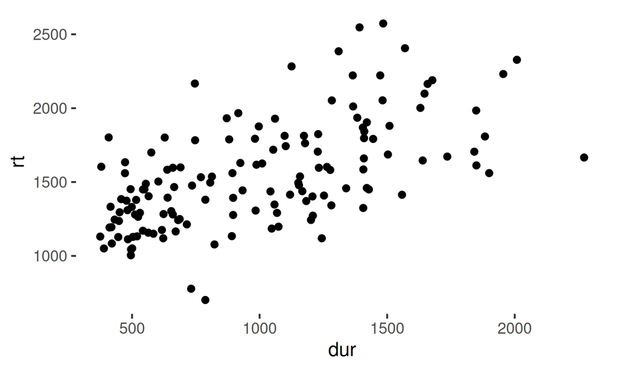

```r
ggplot(d_spellname, aes(x = dur, y = rt)) +
  geom_point() +
  theme(panel.background = element_blank())
```

## Grammatical elements in action

Complete RMarkdown document **1a_gog.Rmd**

Bonus: **1b_gog.Rmd**

## Which layer corresponds to which part of the grammar?

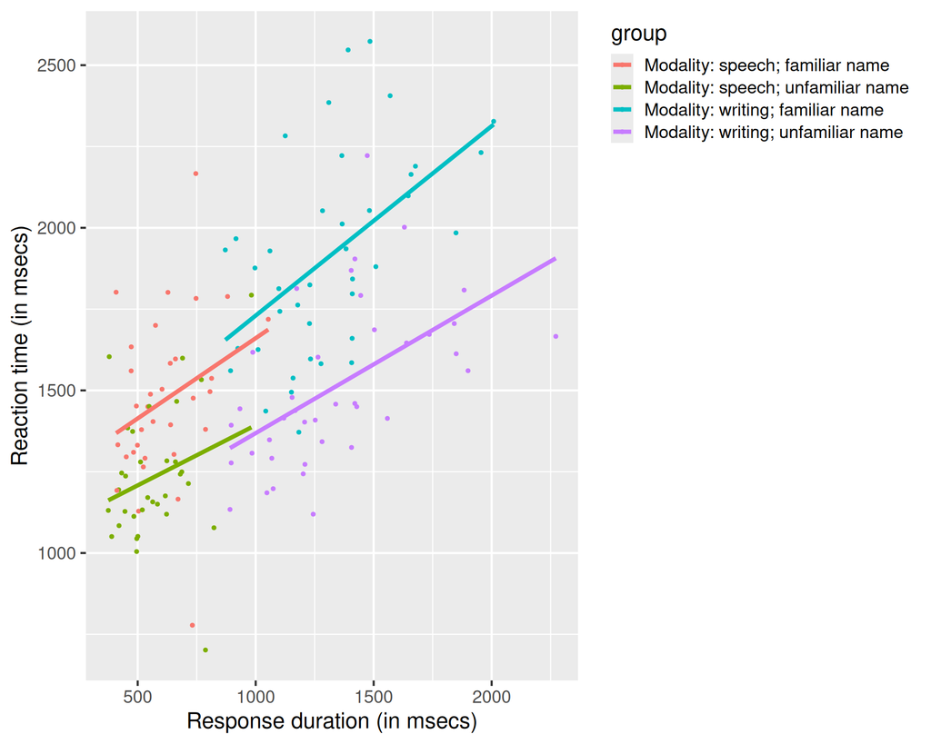

```r
ggplot(d_spellname, aes(x = dur, y = rt, colour = group)) +
  geom_point(size = .75) +
  stat_smooth(method = "lm", se = F) +
  labs(x = "Response duration (in msecs)",
       y = "Reaction time (in msecs)") +
  theme(legend.position = "right",
       legend.justification = "top",
       legend.direction = "vertical")
```

## Aesthetics vs Attributes

## Aesthetics vs Attributes

**Aesthetics**: visual properties mapped to variables (data-driven) e.g. `aes(x = duration, y = time, colour = group)` → colour changes with data

**Attributes**: visual properties set manually (constant) e.g. `geom_point(colour = "blue", size = 2)` → colour is fixed, not mapped to data

*Think*:

Aesthetic = mapping (data → visual)

Attribute = setting (visual → fixed property)

## Aesthetics vs Attributes

- appearance of geometries
- e.g. colour, size, shape
- attributes take properties
- aesthetics take variables

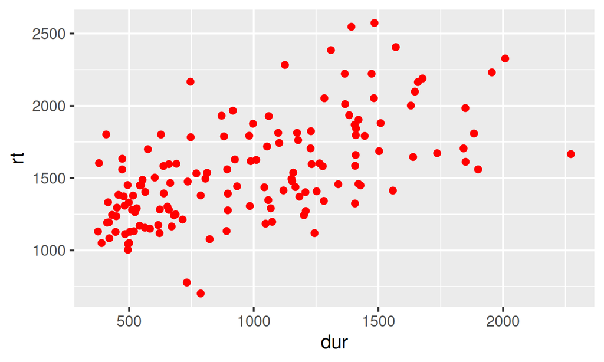

```r
ggplot(d_spellname, aes(x = dur, y = rt)) +
  geom_point(colour = "red")
```

## Aesthetics vs Attributes

- appearance of geometries
- e.g. colour, size, shape
- attributes take properties
- aesthetics take variables

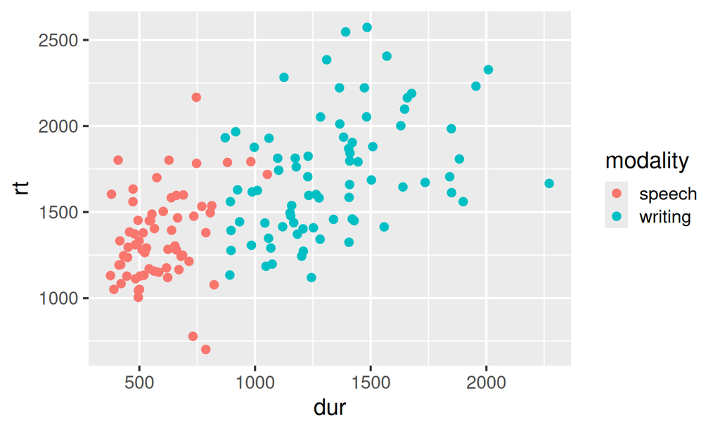

```r
ggplot(d_spellname, aes(x = dur, y = rt)) +
  geom_point(aes(colour = modality))
```

## Aesthetics vs Attributes

- appearance of geometries
- e.g. colour, size, shape
- attributes take properties
- aesthetics take variables

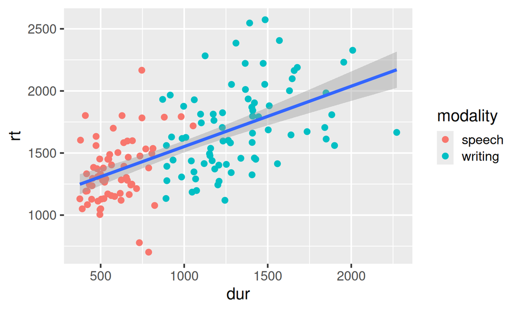

```r
ggplot(d_spellname, aes(x = dur, y = rt)) +
  geom_point(aes(colour = modality)) +
  stat_smooth(method = "lm")
```

## Aesthetics vs Attributes

- appearance of geometries
- e.g. colour, size, shape
- attributes take properties
- aesthetics take variables

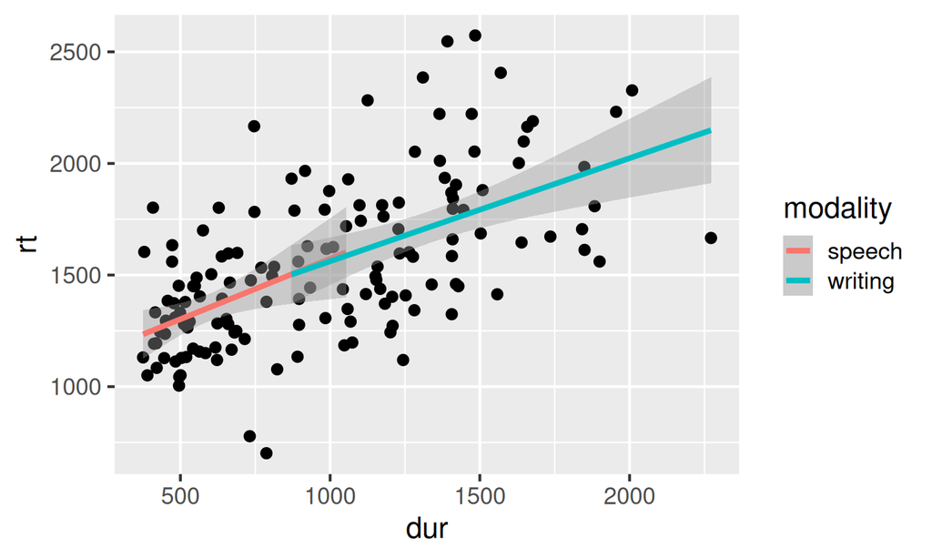

```r
ggplot(d_spellname, aes(x = dur, y = rt)) +
  geom_point() +
  stat_smooth(aes(colour = modality), method = "lm")
```

## Aesthetics vs Attributes

- appearance of geometries
- e.g. colour, size, shape
- attributes take properties
- aesthetics take variables

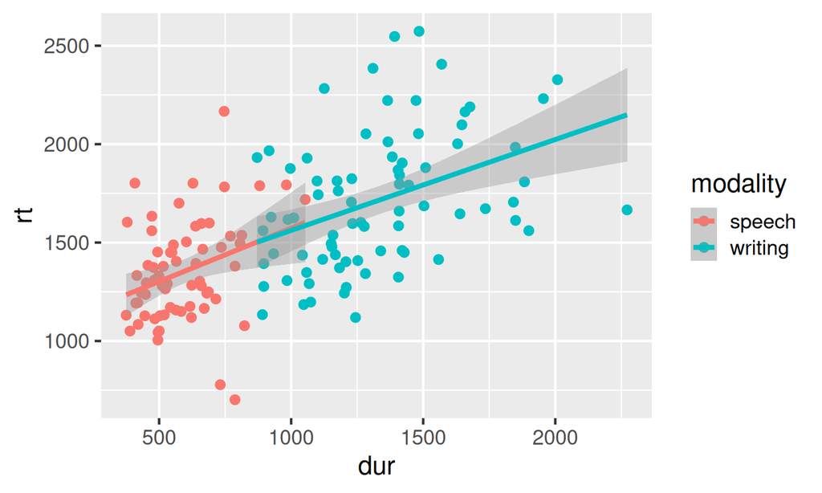

```r
ggplot(d_spellname, aes(x = dur, y = rt)) +
  geom_point(aes(colour = modality)) +
  stat_smooth(aes(colour = modality), method = "lm")
```

## Aesthetics vs Attributes

- appearance of geometries
- e.g. colour, size, shape
- attributes take properties
- aesthetics take variables

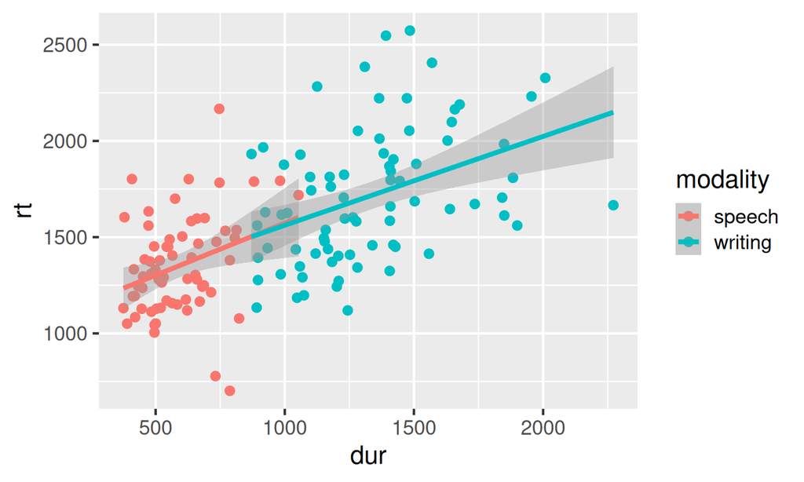

```r
ggplot(d_spellname, aes(x = dur, y = rt, colour = modality)) +
  geom_point() +
  stat_smooth(method = "lm")
```

## Aesthetics vs Attributes

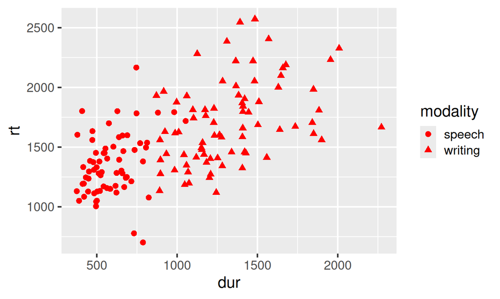

```r
ggplot(d_spellname, aes(x = dur, y = rt, shape = modality)) +
  geom_point(size = 2.5, colour = "red")
```

## Aesthetics vs Attributes

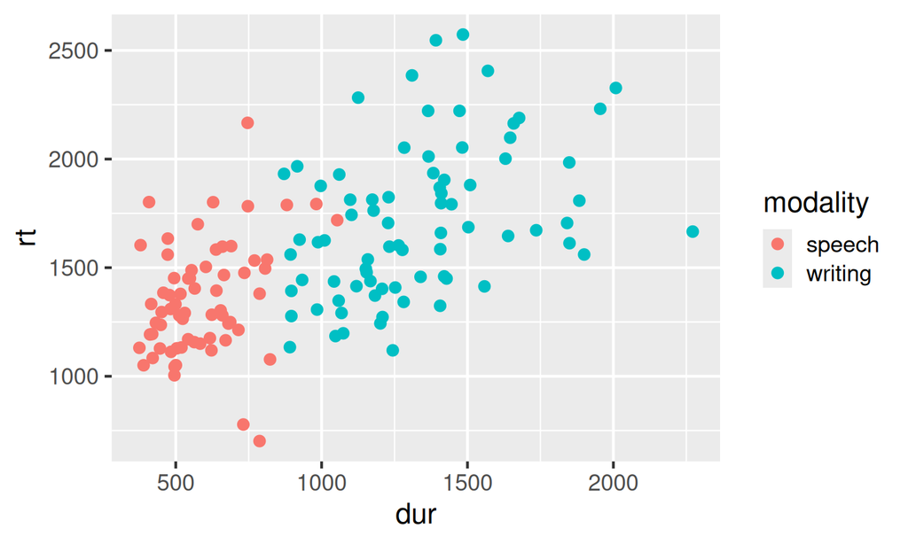

```r
ggplot(d_spellname, aes(x = dur, y = rt, colour = modality)) +
  geom_point(size = 2.5)
```

## Aesthetics vs Attributes

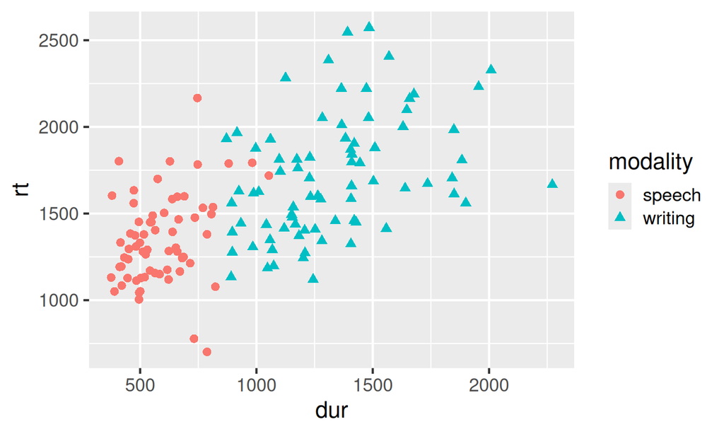

```r
ggplot(d_spellname, aes(x = dur, y = rt, colour = modality, shape = modality))   +
  geom_point(size = 2.5)
```

## Aesthetics vs Attributes

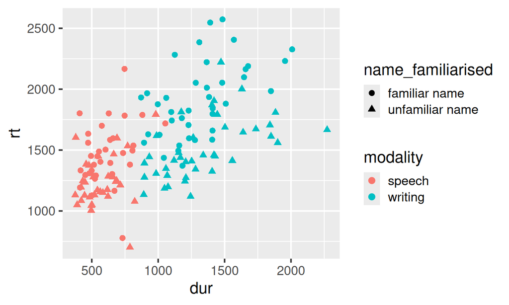

```r
ggplot(d_spellname, aes(x = dur, y = rt, colour = modality, shape = name_familiarised)) +
  geom_point(size = 2.5)
```

## Aesthetics vs Attributes

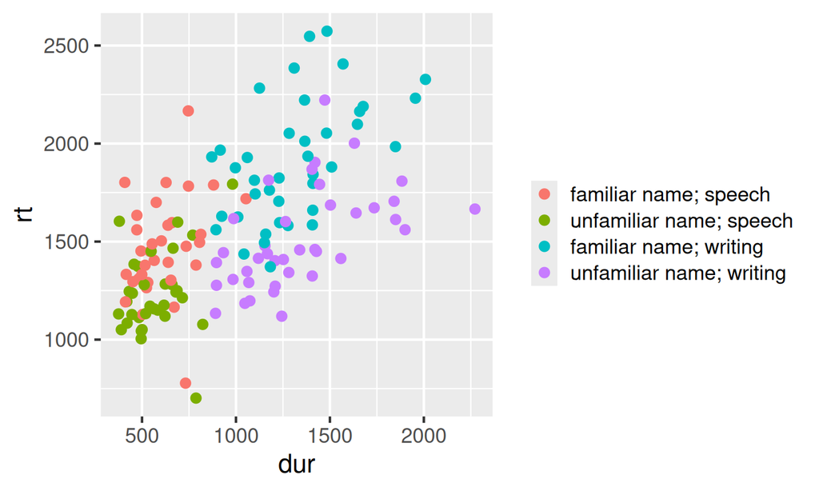

```r
ggplot(d_spellname, aes(x = dur, y = rt, colour = interaction(name_familiarised, modality, sep = "; "))) +
  geom_point(size = 2.5) +
  labs(colour = "")
```

## Aesthetics

### typically `x`, `y`, `colour`, `fill`, `group`

- some are required by geometries; others are optional
- continuous vs discrete variables:
  - e.g. shape and label can only be used for categorical values
- should be chosen to facilitate comprehension
- scatterplot: `geom_point()`

```
x, y, shape, colour, fill, size, alpha, stroke, group
```

- barplot: `geom_bar()`

```
x, y, colour, fill, linewidth, linetype, alpha, width, group
```

- boxplot: `geom_boxplot()`

```
x, y, lower, xlower, upper, xupper, middle, xmiddle, ymin,
xmin, ymax, xmax, weight, colour, fill, size, alpha, shape,
linetype, linewidth, width, group
```

## Aesthetics vs Attributes

Complete RMarkdown documents

- **2a_attributes.R** for attributes
- **2b_aesthetics.R** for aesthetics

## Continuous vs Categorical Variables

The type—`<dbl>` and `<chr>`—determines which aesthetics you can map to it, and how `ggplot2` interprets it visually.

```r
glimpse(d_spellname)
```

```
Rows: 144
Columns: 7
$ ppt_id            <dbl> 40, 40, 41, 41, 42, 42, 43, 43, 44, 44, 45, 45, 46, …
$ name_familiarised <chr> "familiar name", "unfamiliar name", "familiar name",…
$ ppt_vocab         <dbl> 0.9500, 0.9500, 1.0000, 1.0000, 0.9250, 0.9250, 0.90…
$ modality          <chr> "speech", "speech", "speech", "speech", "speech", "s…
$ rt                <dbl> 1476.1579, 1249.5161, 1404.2000, 1170.5397, 1283.455…
$ dur               <dbl> 735.2632, 686.8065, 565.0400, 542.4603, 623.5147, 63…
$ group             <chr> "Modality: speech; familiar name", "Modality: speech…
```

`ggplot2` automatically detects variable type:

- Continuous: numeric variables (e.g., age, height, RT, temperature)
- Categorical: factors or character variables (e.g., group, species, modality)

Sometimes categorical variables are coded as numbers; condition = 1, 2, 3, 4; male = 1, female = 2

## Continuous Variables: Visual Decoding

See Wong (2010) page 665

- Examples: age, height, RT, duration, temperature
- Convey *magnitude* and *order*

Best represented using gradual or quantitative encodings:

- position on an aligned scale (x, y)
- length, angle, area, volume
- colour gradients (e.g., light → dark)
  - monochromatic colour spectrum (saturation, grey scale)
  - pure spectrum colours
- size (circle area, line width)

## Continuous Variables: Position on common scale

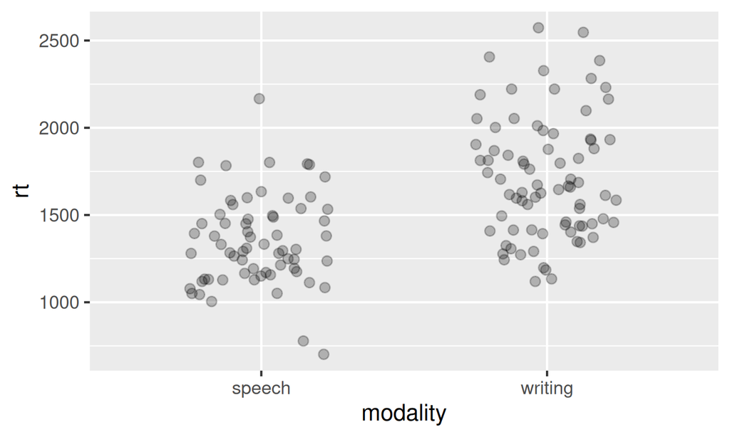

```r
ggplot(d_spellname, aes(x = modality, y = rt)) +
  geom_jitter()
```

## Continuous Variables: Non-aligned scale

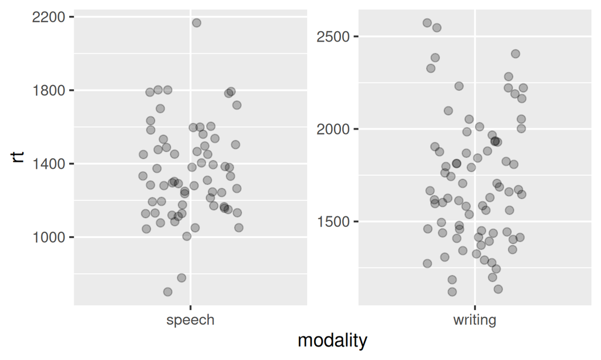

```r
ggplot(d_spellname, aes(x = modality, y = rt)) +
  geom_jitter() +
  facet_wrap(~modality, scales = "free")
```

## Continuous Variables: Colour gradients

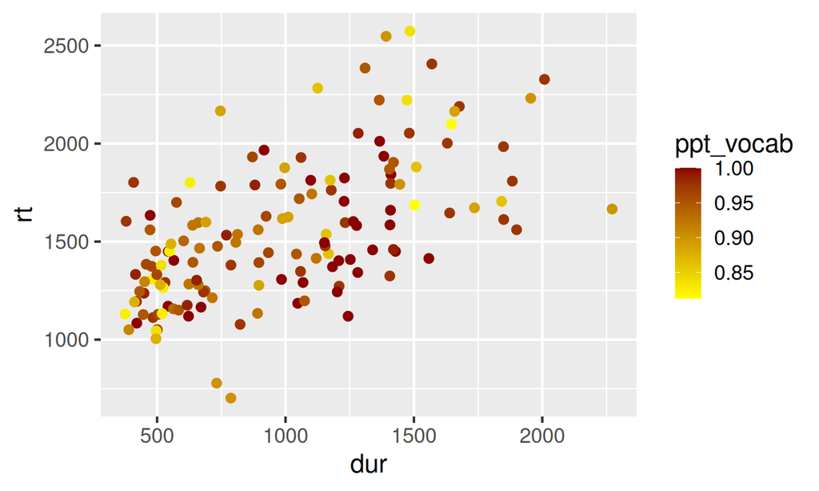

```r
ggplot(d_spellname, aes(x = dur,
                        y = rt,
                        colour = ppt_vocab)) +
  geom_point() +
  scale_colour_gradient(high = "darkred", low = "yellow")
```

## Categorical Variables: Visual Decoding

See Wong (2010) page 665

- Examples of categorical variables: condition, response modality, species
- Convey *difference in kind*, not quantity

Best represented using distinct encodings:

- position on discrete axis (x)
- distinct shapes
- distinct hues (qualitative color palette)

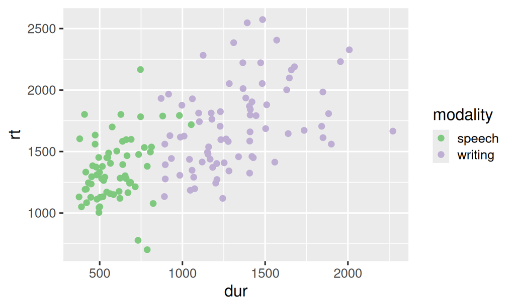

```r
ggplot(d_spellname, aes(x = dur,
                        y = rt,
                        colour = modality)) +
  geom_point() +
  scale_colour_brewer(type = "qual")
```

## Categorical Variables: `text` / `labels`

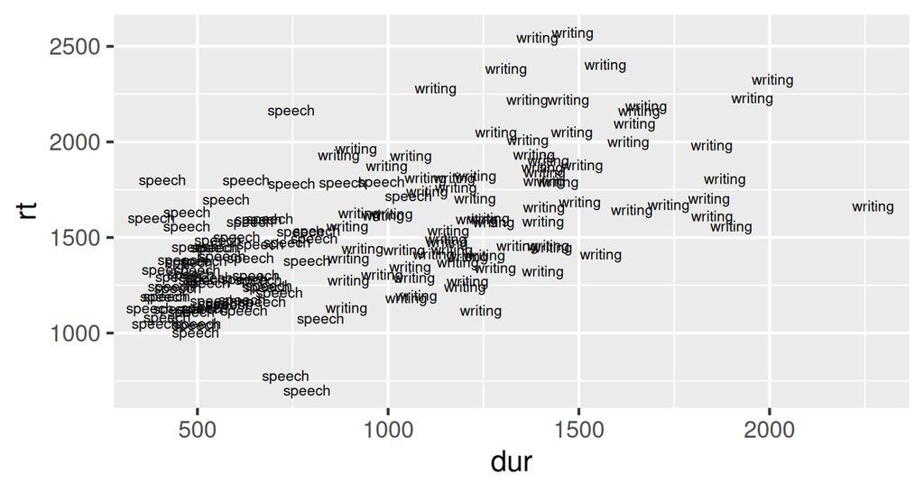

```r
ggplot(d_spellname, aes(x = dur,
                        y = rt,
                        label = modality)) +
  geom_text(size = 3)
```

- qualitative colours, labels, line colours
- sequential colours, shape outlines, line type
- filled shapes, hatching (shading with lines), line width

## Categorical Variables: `shape`

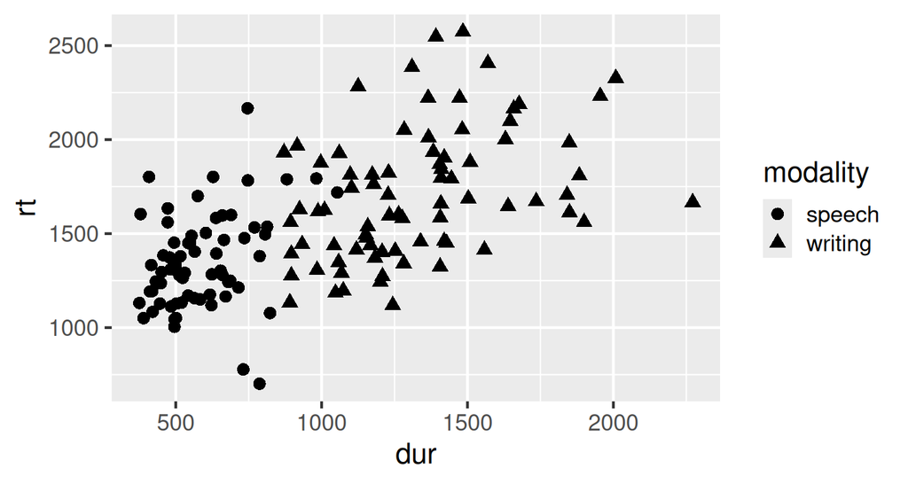

```r
ggplot(d_spellname, aes(x = dur,
                        y = rt,
                        shape = modality)) +
  geom_point(size = 3)
```

- qualitative colours, labels, line colours
- sequential colours, shape outlines, line type
- filled shapes, hatching (shading with lines), line width

## Categorical Variables: Hue

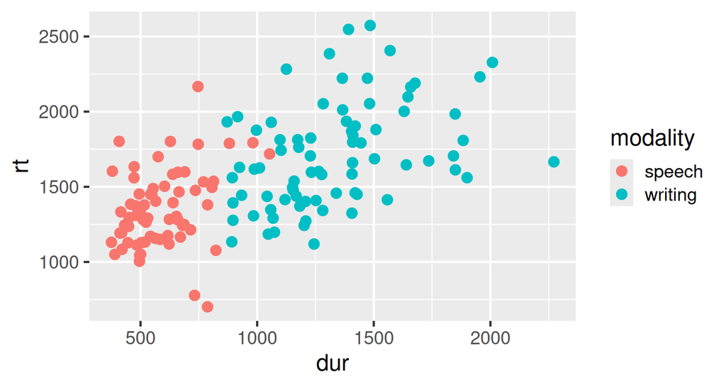

```r
ggplot(d_spellname, aes(x = dur,
                        y = rt,
                        colour = modality)) +
  geom_point(size = 3)
```

- qualitative colours, labels, line colours
- sequential colours, shape outlines, line type
- filled shapes, hatching (shading with lines), line width